# FINETUNING BERT FOR SEMANTIC ROLE LABELLING

The link of model checkpoint can be found here: https://drive.google.com/drive/folders/1qm_GnZLoB2kFT8ybDTCo79IE-GHPtBk1?usp=sharing

```python
! git clone https://github.com/amee342/semantic_role_labeling.git
```

```
Cloning into 'semantic_role_labeling'...
remote: Enumerating objects: 93, done.
remote: Counting objects: 100% (93/93), done.
remote: Compressing objects: 100% (80/80), done.
remote: Total 93 (delta 39), reused 29 (delta 7), pack-reused 0 (from 0)
Receiving objects: 100% (93/93), 5.43 MiB | 13.04 MiB/s, done.
Resolving deltas: 100% (39/39), done.
```

```python
cd semantic_role_labeling/
```

```
/content/semantic_role_labeling
```

```python
!pip install -q transformers datasets accelerate evaluate seqeval
```

```
     ━━━━━━━━━━━━━━━━━━━━━━━━━━━━━━━━━━━━━━━━ 43.6/43.6 kB 1.3 MB/s eta 0:00:00
  Preparing metadata (setup.py) ... done
   ━━━━━━━━━━━━━━━━━━━━━━━━━━━━━━━━━━━━━━━━ 84.1/84.1 kB 2.7 MB/s eta 0:00:00
```

```python
# set up saving repo in drive
from google.colab import drive
drive.mount('/content/drive')
```

```python
# Argument setting
model_checkpoint = "distilbert/distilbert-base-uncased"
batch_size = 16
task = "SRL"
training_epoch = 10
out_dir = "/content/drive/MyDrive/SRL"
```

There is an repository in drive called "SRL" for storing finetuned models

```python
import transformers
from transformers import AutoTokenizer, AutoModelForTokenClassification, TrainingArguments, Trainer, set_seed
from transformers import DataCollatorForTokenClassification
from evaluate import load
from datasets import Dataset, DatasetDict
import numpy as np
from sklearn.metrics import precision_recall_fscore_support, accuracy_score, confusion_matrix, classification_report
import matplotlib.pyplot as plt
import seaborn as sns
import datetime
import copy
import torch
from transformers import TrainerCallback
import os, json
import pandas as pd
import matplotlib.pyplot as plt
import seaborn as sns
from typing import List, Tuple, Union
```

```python
# Set random seed!

SEED = 0
set_seed(SEED)
```

## Load and Parse CONLLU dataset

```python
def load_conll_sentences(path: str):

    sentences = []
    sent = []

    with open(path, "r", encoding="utf-8") as f:
        for line in f:

            line = line.rstrip("\n")

            #  save previous sentence
            # at boundary between 2 sentences
            if line.strip() == "":
                if sent:
                    sentences.append(sent)
                    sent = []
                continue

            # skip comments
            if line.startswith("#"):
                continue

            cols = line.split("\t")
            sent.append(cols)

    if sent:
        sentences.append(sent)

    return sentences
```

## Preprocessing

```python
def count_sentences_and_tokens(sentences: List):
  """
  Return number of sentences (n_sent)
  and number of tokens from these sentences (n_token)
  """
  n_sent = len(sentences)
  n_token = sum(len(s) for s in sentences)

  return n_sent, n_token
```

### Replicate each sentence for each predicate

```python
def find_predicate_index(sent,
                           label_col,
                           ):
  predicate_markers=("V", "C-V" )
  for i, row in enumerate(sent):

    if len(row) > label_col and row[label_col] in predicate_markers:
      return i
  return None
```

```python
def replicate_sentences(sentences,
                        base_cols: int=11):

  instances = []
  """
  base_cols: the column with specified predicates
  """
  for sent in sentences:

    # check the maximum columns in specific sentence
    # assume it's consistent per token row
    max_cols = max(len(r) for r in sent)

    # nr of predicate-specific label columns
    k = max(0, max_cols-base_cols)

    if k == 0 :
      # sentence has no predicate
      continue

    # rely on k
    for j in range(k):
      label_col = base_cols + j  # 0-based index

      pred_index = find_predicate_index(sent, label_col)

      # fallback if no V marker found
      if pred_index is None:
        continue
        #pred_index = next((i for i,r in enumerate(sent) if len(r) > 9 and r[9] not in ("_", "-", "")), None)


      tokens = [r[1] for r in sent] # FORM column

      #labels = [(r[label_col] if len(r) > label_col else "O") for r in sent]
      labels = [
                    "O" if (len(r) <= label_col or r[label_col] == "_" or r[label_col] == "")
                    else r[label_col]
                    for r in sent
              ]

      instances.append({
                "tokens": tokens,
                "predicate_index": pred_index,
                "labels": labels,
            })
  return instances
```

```python
def load_and_preprocess(path:str):
  sentences = load_conll_sentences(path)
  before_s, before_t = count_sentences_and_tokens(sentences)

  instances = replicate_sentences(sentences)
  after_s, after_t = count_sentences_and_tokens(instances)

  return {
        "sentences": sentences,
        "instances": instances,
        "stats": {
            "before_sentences": before_s,
            "before_tokens": before_t,
            "after_instances": after_s,
            "after_tokens": after_t
        }
    }
```

### Tokenizer

```python
tokenizer = AutoTokenizer.from_pretrained(model_checkpoint)
```

```
vocab.txt: 0.00B [00:00, ?B/s]
```

```
tokenizer.json: 0.00B [00:00, ?B/s]
```

```python
# check if tokenizer is backed by RUST
assert isinstance(tokenizer, transformers.PreTrainedTokenizerFast)
```

### Add predicate encoding

```python
def make_predicate_query(tokens, pred_idx, window=1):
    start = max(0, pred_idx - window)
    end = min(len(tokens), pred_idx + window + 1)
    return tokens[start:end]  # list[str]
```

```python
labels_all_tokens = True  # usually False is safest

def tokenize_and_align_labels(examples):

    sent_batch = examples["tokens"]               # list[list[str]]
    labels_batch = examples["labels_str"]         # string labels
    pred_idx_batch = examples["predicate_index"]  # list[int]

    # Build predicate query (Sequence B)
    query_batch = [
        make_predicate_query(tokens, pred_idx, window=1)
        for tokens, pred_idx in zip(sent_batch, pred_idx_batch)
    ]

    # Tokenize sentence pairs
    tokenized = tokenizer(
        sent_batch,
        query_batch,
        is_split_into_words=True,
        truncation=True,
    )

    all_label_ids = []

    for i, labels in enumerate(labels_batch):

        word_ids = tokenized.word_ids(batch_index=i)
        #print(word_ids)
        seq_ids = tokenized.sequence_ids(i)

        prev_word = None
        label_ids = []

        for word_idx, seq_id in zip(word_ids, seq_ids):

            if word_idx is None:
                label_ids.append(-100)

            elif seq_id != 0:
                # Ignore sequence B and special tokens
                label_ids.append(-100)

            elif word_idx != prev_word:
                if word_idx == pred_idx_batch[i]:
                    label_ids.append(label2id["O"])
                else:
                    label_ids.append(label2id[labels[word_idx]])
            else:
                if labels_all_tokens:
                    if word_idx == pred_idx_batch[i]:
                        label_ids.append(label2id["O"])
                    else:
                        label_ids.append(label2id[labels[word_idx]])
                else:
                    label_ids.append(-100)

        all_label_ids.append(label_ids)

    tokenized["labels"] = all_label_ids
    return tokenized
```

### Data split

```python
TRAIN_PATH = "/content/semantic_role_labeling/data/en_ewt-up-train.conllu"
DEV_PATH   = "/content/semantic_role_labeling/data/en_ewt-up-dev.conllu"
TEST_PATH  = "/content/semantic_role_labeling/data/en_ewt-up-test.conllu"

# Load and replicate sentences
train_sents = load_and_preprocess(TRAIN_PATH)
dev_sents   = load_and_preprocess(DEV_PATH)
test_sents  = load_and_preprocess(TEST_PATH)

# put into HF Dataset
train_set = Dataset.from_list(train_sents['instances'])
dev_set = Dataset.from_list(dev_sents['instances'])
test_set = Dataset.from_list(test_sents['instances'])

# filter bad instances
train_set = train_set.filter(lambda ex: ex["predicate_index"] is not None)
dev_set = dev_set.filter(lambda ex: ex["predicate_index"] is not None)
test_set = test_set.filter(lambda ex: ex["predicate_index"] is not None)

# rename column
train_set = train_set.rename_column("labels", "labels_str")
dev_set = dev_set.rename_column("labels", "labels_str")
test_set = test_set.rename_column("labels", "labels_str")
```

```python
# combine into DatasetDict
datasets = DatasetDict({
    "train": train_set,
    "dev": dev_set,
    "test": test_set
})
```

```python
for i in datasets:
  print(f"{i}: {datasets[i]}")
```

```
train: Dataset({
    features: ['tokens', 'predicate_index', 'labels_str'],
    num_rows: 40481
})
dev: Dataset({
    features: ['tokens', 'predicate_index', 'labels_str'],
    num_rows: 4977
})
test: Dataset({
    features: ['tokens', 'predicate_index', 'labels_str'],
    num_rows: 4799
})
```

```python
label_list = sorted(
    set(
        l
        for split in datasets.values()
        for labels in split["labels_str"]
        for l in labels
    )
)
label2id = {l:i for i,l in enumerate(label_list)}
id2label = {i:l for l,i in label2id.items()}
```

```python
label2id
```

### Inspect tokenized sentences

```python
tokenized_datasets = datasets.map(tokenize_and_align_labels, batched=True)
```

```python
def decode_label(label_ids):
    return [id2label[l] if l != -100 else '[SEP]' for l in label_ids ]
def print_tokenized_sentence(tokenized_ds, index:list[int] = None):
  for i in index:
    print(f"Instance {i}:" +" ".join(tokenizer.convert_ids_to_tokens(tokenized_ds[i]['input_ids'])))
    print(f"Labels: {decode_label(tokenized_ds[i]['labels'])})")
    print(f"Predicate index: {tokenized_ds[i]['predicate_index']}")
```

#### Sanity check on preprocessed input

For each instance, the labels of normal tokens remain, but the label of predicates would transform to '0'. Besides, the tokenized sequences are padded with a windown around the predicate. The size of the windown is specified as 1. This setting allows the model to know which token in the sequence is predicate without classifying them. Additionally, the classes of second sequence are ignored (-100).

```python
print_tokenized_sentence(tokenized_datasets['train'], [1, 10])
```

```
Instance 1:[CLS] [ this killing of a respected cleric will be causing us trouble for years to come . ] [SEP] this killing of [SEP]
Labels: ['[SEP]', 'O', 'O', 'O', 'O', 'O', 'O', 'ARG1', 'O', 'O', 'O', 'O', 'O', 'O', 'O', 'O', 'O', 'O', 'O', '[SEP]', '[SEP]', '[SEP]', '[SEP]', '[SEP]'])
Predicate index: 2
Instance 10:[CLS] two of them were being run by 2 officials of the ministry of the interior ! [SEP] being run by [SEP]
Labels: ['[SEP]', 'ARG1', 'O', 'O', 'O', 'O', 'O', 'O', 'O', 'ARG0', 'O', 'O', 'O', 'O', 'O', 'O', 'O', '[SEP]', '[SEP]', '[SEP]', '[SEP]', '[SEP]'])
Predicate index: 5
```

## Fine Tune Model

```python
model = AutoModelForTokenClassification.from_pretrained(model_checkpoint,
                                                        num_labels=len(label_list),
                                                        id2label=id2label,
                                                        label2id=label2id,)
model.resize_token_embeddings(len(tokenizer))
```

[output not shown]

```
Embedding(30522, 768, padding_idx=0)
```

```python
model_name = model_checkpoint.split("/")[-1]
current_time=datetime.datetime.now().strftime("%Y%m%d-%H%M%S")
args = TrainingArguments(
    f"{out_dir}/{model_name}-finetuned-{task}-{current_time}",
    eval_strategy = "epoch",
    learning_rate=2e-5,
    per_device_train_batch_size=batch_size,
    per_device_eval_batch_size=batch_size*2,
    gradient_accumulation_steps=2,
    num_train_epochs=training_epoch,
    weight_decay=0.01,
    seed=SEED,
    logging_strategy="steps",
    logging_steps=50,
    report_to="none",
    save_strategy="no"

)
```

### Set up metric

```python
# batch dataset
data_collator = DataCollatorForTokenClassification(tokenizer)
```

```python
def compute_metrics(eval_pred):
    logits, label_ids = eval_pred
    pred_ids = np.argmax(logits, axis=-1)

    # Flatten, ignoring -100
    y_true = []
    y_pred = []
    for preds, labs in zip(pred_ids, label_ids):
        for p, l in zip(preds, labs):
            if l == -100:
                continue
            y_true.append(int(l))
            y_pred.append(int(p))

    # macro = average across labels equally (good for imbalanced SRL)
    p_macro, r_macro, f1_macro, _ = precision_recall_fscore_support(
        y_true, y_pred, average="macro", zero_division=0
    )
    # micro = overall token accuracy-ish (good as a second number)
    p_micro, r_micro, f1_micro, _ = precision_recall_fscore_support(
        y_true, y_pred, average="micro", zero_division=0
    )
    acc = accuracy_score(y_true, y_pred)

    return {
        "accuracy": acc,
        "precision_macro": p_macro,
        "recall_macro": r_macro,
        "f1_macro": f1_macro,
        "precision_micro": p_micro,
        "recall_micro": r_micro,
        "f1_micro": f1_micro,
    }
```

```python
# set up logging per global step
class JSONLMetricsCallback(TrainerCallback):
    def __init__(self, out_dir, filename="metrics.jsonl"):
        self.path = os.path.join(out_dir, filename)
        os.makedirs(out_dir, exist_ok=True)

    def _write(self, record):
        with open(self.path, "a", encoding="utf-8") as f:
            f.write(json.dumps(record) + "\n")

    def on_log(self, args, state, control, logs=None, **kwargs):
        if not logs:
            return
        rec = {"event": "log", "epoch": state.epoch, "global_step": state.global_step, **logs}
        self._write(rec)

    def on_evaluate(self, args, state, control, metrics=None, **kwargs):
        if not metrics:
            return
        rec = {"event": "eval", "epoch": state.epoch, "global_step": state.global_step, **metrics}
        self._write(rec)
```

```python
# set up logging for the best model at the end
class SaveBestAtEndCallback(TrainerCallback):
    def __init__(self, metric_name="eval_f1_macro", greater_is_better=True):
        self.metric_name = metric_name
        self.greater_is_better = greater_is_better
        self.best_metric = None
        self.best_state_dict_cpu = None

    def on_evaluate(self, args, state, control, metrics=None, model=None, **kwargs):
        if metrics is None or model is None or self.metric_name not in metrics:
            return

        current = metrics[self.metric_name]
        is_better = (
            self.best_metric is None or
            (current > self.best_metric if self.greater_is_better else current < self.best_metric)
        )
        if is_better:
            self.best_metric = current
            # Move weights to CPU and store in RAM
            self.best_state_dict_cpu = {k: v.detach().cpu().clone() for k, v in model.state_dict().items()}

    def on_train_end(self, args, state, control, model=None, **kwargs):
        # Put best weights back into model at the end
        if model is not None and self.best_state_dict_cpu is not None:
            model.load_state_dict(self.best_state_dict_cpu)
```

### Training

In the training phase, the best model is selected depending on the f1 macro. The reason for selecting the metrics is due to the class imbalance characteristics of the dataset.

```python
import inspect
print(inspect.signature(Trainer.__init__))
```

```
(self, model: transformers.modeling_utils.PreTrainedModel | torch.nn.modules.module.Module | None = None, args: transformers.training_args.TrainingArguments | None = None, data_collator: collections.abc.Callable[[list[typing.Any]], dict[str, typing.Any]] | None = None, train_dataset: Union[torch.uti…
```

```python
# setting for best checkpoint
# choose f1 macro as the criteria
best_cb = SaveBestAtEndCallback(metric_name="eval_f1_macro", greater_is_better=True)

trainer = Trainer(
    model=model,
    args=args,
    train_dataset=tokenized_datasets["train"],
    eval_dataset=tokenized_datasets["dev"],
    processing_class=tokenizer,
    data_collator=data_collator,
    compute_metrics=compute_metrics,
    callbacks=[
        JSONLMetricsCallback(args.output_dir),
        best_cb,
    ],
)

trainer.train()
```

[12660/12660 51:04, Epoch 10/10]

| Epoch | Training Loss | Validation Loss | Accuracy | Precision Macro | Recall Macro | F1 Macro | Precision Micro | Recall Micro | F1 Micro |
| --- | --- | --- | --- | --- | --- | --- | --- | --- | --- |
| 1 | 0.264082 | 0.140647 | 0.963614 | 0.333490 | 0.296575 | 0.303597 | 0.963614 | 0.963614 | 0.963614 |
| 2 | 0.189493 | 0.118203 | 0.968459 | 0.407469 | 0.356672 | 0.363813 | 0.968459 | 0.968459 | 0.968459 |
| 3 | 0.135119 | 0.111562 | 0.970972 | 0.425690 | 0.392206 | 0.397930 | 0.970972 | 0.970972 | 0.970972 |
| 4 | 0.117389 | 0.109975 | 0.972271 | 0.451979 | 0.434521 | 0.433281 | 0.972271 | 0.972271 | 0.972271 |
| 5 | 0.090500 | 0.115808 | 0.971944 | 0.471397 | 0.438454 | 0.446346 | 0.971944 | 0.971944 | 0.971944 |
| 6 | 0.071166 | 0.120371 | 0.972865 | 0.462764 | 0.447688 | 0.450314 | 0.972865 | 0.972865 | 0.972865 |
| 7 | 0.071828 | 0.121086 | 0.973648 | 0.495427 | 0.451289 | 0.459897 | 0.973648 | 0.973648 | 0.973648 |
| 8 | 0.064119 | 0.126233 | 0.973519 | 0.494852 | 0.457393 | 0.465070 | 0.973519 | 0.973519 | 0.973519 |
| 9 | 0.053805 | 0.129404 | 0.973459 | 0.497365 | 0.464603 | 0.469864 | 0.973459 | 0.973459 | 0.973459 |
| 10 | 0.048009 | 0.130256 | 0.973614 | 0.499037 | 0.461179 | 0.469434 | 0.973614 | 0.973614 | 0.973614 |

```
TrainOutput(global_step=12660, training_loss=0.13290346068511077, metrics={'train_runtime': 3064.2226, 'train_samples_per_second': 132.109, 'train_steps_per_second': 4.132, 'total_flos': 7531290906266820.0, 'train_loss': 0.13290346068511077, 'epoch': 10.0})
```

```python
trainer.save_model(f"{out_dir}/best_model")
tokenizer.save_pretrained(f"{out_dir}/best_model")

# Optional: also save the best metric value
with open(f"{out_dir}/best_model/best_metric.json", "w") as f:
    json.dump({"best_eval_f1_macro": best_cb.best_metric}, f, indent=2)
```

```python
records = []

with open("/content/drive/MyDrive/SRL/distilbert-base-uncased-finetuned-SRL-20260305-154721/metrics.jsonl", "r") as f:
    for line in f:
        records.append(json.loads(line))

df = pd.DataFrame(records)
train_df = df[df["event"] == "log"].copy()
eval_df = df[df["event"] == "eval"].copy()
train_df = train_df.groupby("epoch", as_index=False)["loss"].mean()
```

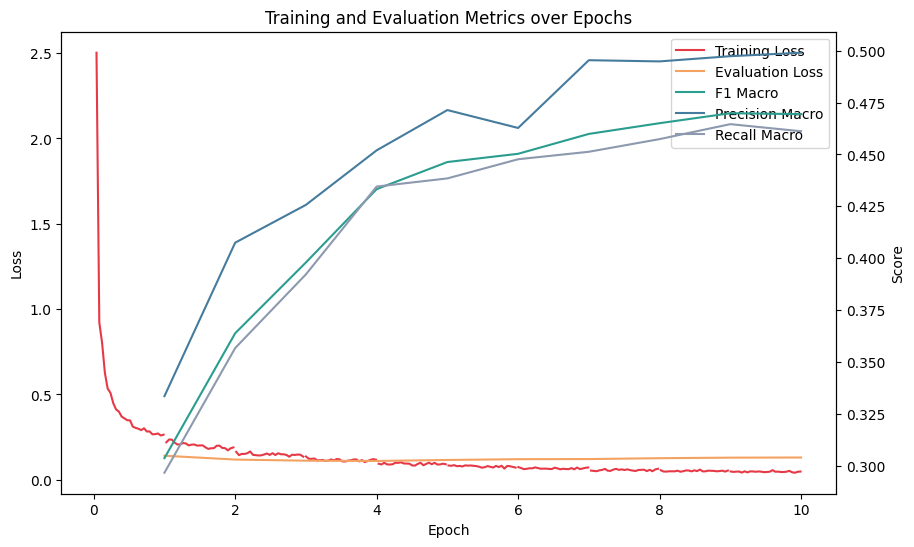

```python
plt.figure(figsize=(10,6))

ax1 = plt.gca()
ax1.plot(train_df["epoch"], train_df["loss"],color="#E63946", label="Training Loss")
ax1.plot(eval_df["epoch"], eval_df["eval_loss"], color="#F4A261", label="Evaluation Loss")
ax1.set_xlabel("Epoch")
ax1.set_ylabel("Loss")


ax2 = ax1.twinx()
ax2.plot(eval_df["epoch"], eval_df["eval_f1_macro"], color="#2A9D8F", label="F1 Macro")
ax2.plot(eval_df["epoch"], eval_df["eval_precision_macro"], color="#457B9D", label="Precision Macro")
ax2.plot(eval_df["epoch"], eval_df["eval_recall_macro"], color="#8D99AE", label="Recall Macro")
ax2.set_ylabel("Score")

lines1, labels1 = ax1.get_legend_handles_labels()
lines2, labels2 = ax2.get_legend_handles_labels()

ax1.legend(lines1 + lines2, labels1 + labels2, loc="best")

plt.title("Training and Evaluation Metrics over Epochs")
plt.show()
```

## Testing

```python
pred_output = trainer.predict(tokenized_datasets["test"])
```

```python
logits = pred_output.predictions
label_ids = pred_output.label_ids

pred_ids = np.argmax(logits, axis=-1) # flattening

y_true = []
y_pred = []

for preds, labs in zip(pred_ids, label_ids):
    for p, l in zip(preds, labs):
        if l == -100:
            continue
        y_true.append(int(l))
        y_pred.append(int(p))
```

```python
all_label_ids = list(range(len(id2label)))
cm = confusion_matrix(y_true, y_pred, labels=all_label_ids)
```

```python
cm_df = pd.DataFrame(cm, index=id2label.values(), columns=id2label.values())
```

### Classification report

```python
true_labels_names = [label_list[i] for i in y_true]
true_preds_names = [label_list[i] for i in y_pred]
print(classification_report(
    true_labels_names,
    true_preds_names,
    digits=4
))
```

```
              precision    recall  f1-score   support

        ARG0     0.8417    0.8905    0.8654      1899
        ARG1     0.8632    0.8810    0.8720      3647
    ARG1-DSP     0.0000    0.0000    0.0000         4
        ARG2     0.8011    0.7961    0.7986      1285
        ARG3     0.6066    0.4684    0.5286        79
        ARG4     0.6618    0.6618    0.6618        68
        ARG5     0.0000    0.0000    0.0000         1
        ARGA     0.0000    0.0000    0.0000         2
    ARGM-ADJ     0.7773    0.7008    0.7371       254
    ARGM-ADV     0.6694    0.6122    0.6395       526
    ARGM-CAU     0.5645    0.7292    0.6364        48
    ARGM-COM     0.3889    0.4375    0.4118        16
    ARGM-CXN     0.7333    0.9167    0.8148        12
    ARGM-DIR     0.4600    0.4894    0.4742        47
    ARGM-DIS     0.7665    0.7704    0.7684       196
    ARGM-EXT     0.7570    0.7714    0.7642       105
    ARGM-GOL     0.6000    0.2069    0.3077        29
    ARGM-LOC     0.6216    0.6216    0.6216       259
    ARGM-LVB     0.7639    0.7971    0.7801        69
    ARGM-MNR     0.5723    0.5793    0.5758       164
    ARGM-MOD     0.9482    0.9786    0.9632       468
    ARGM-NEG     0.9233    0.9821    0.9518       392
    ARGM-PRD     0.3947    0.3000    0.3409        50
    ARGM-PRP     0.6250    0.6098    0.6173        82
    ARGM-PRR     0.7571    0.6883    0.7211        77
    ARGM-TMP     0.7908    0.8515    0.8200       586
      C-ARG0     0.0000    0.0000    0.0000         3
      C-ARG1     0.7447    0.6140    0.6731        57
  C-ARG1-DSP     0.0000    0.0000    0.0000         1
      C-ARG2     0.4444    0.5714    0.5000         7
      C-ARG3     0.0000    0.0000    0.0000         2
  C-ARGM-CXN     0.6250    1.0000    0.7692         5
  C-ARGM-LOC     0.0000    0.0000    0.0000         1
         C-V     0.7059    0.7500    0.7273        16
           O     0.9913    0.9899    0.9906    101295
      R-ARG0     0.9242    0.9104    0.9173        67
      R-ARG1     0.7333    0.8462    0.7857        52
      R-ARG2     0.0000    0.0000    0.0000         1
  R-ARGM-ADJ     0.0000    0.0000    0.0000         1
  R-ARGM-ADV     0.0000    0.0000    0.0000         1
  R-ARGM-DIR     0.0000    0.0000    0.0000         1
  R-ARGM-LOC     0.6667    0.6667    0.6667         9
  R-ARGM-MNR     0.0000    0.0000    0.0000         8
  R-ARGM-TMP     0.0000    0.0000    0.0000         2
           V     0.0000    0.0000    0.0000         3

    accuracy                         0.9744    111897
   macro avg     0.4828    0.4909    0.4823    111897
weighted avg     0.9743    0.9744    0.9742    111897
```

### Confusion matrix with "O"

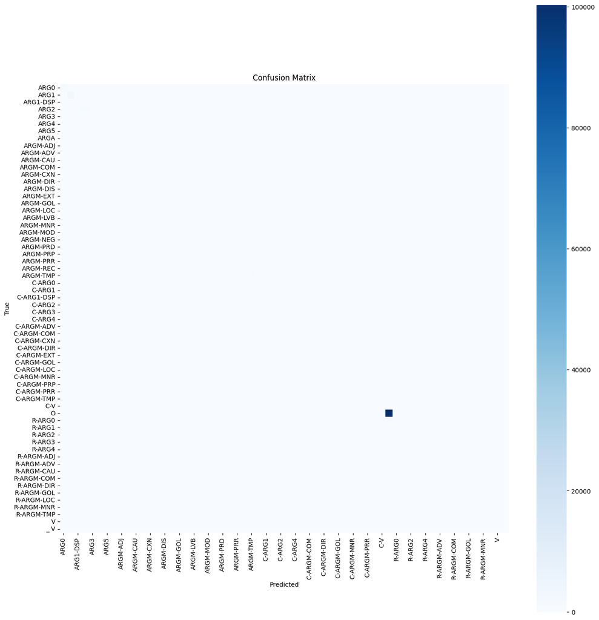

```python
plt.figure(figsize=(14, 14))
sns.heatmap(
    cm_df,              # your pandas DataFrame
    cmap="Blues",
    square=True,
    cbar=True
)

plt.xlabel("Predicted")
plt.ylabel("True")
plt.title("Confusion Matrix")

plt.tight_layout()

plt.savefig(f"{out_dir}/best_model/confusion_matrix.png", dpi=300)
plt.show()
plt.close()
```

### Confusion matrix without "O"

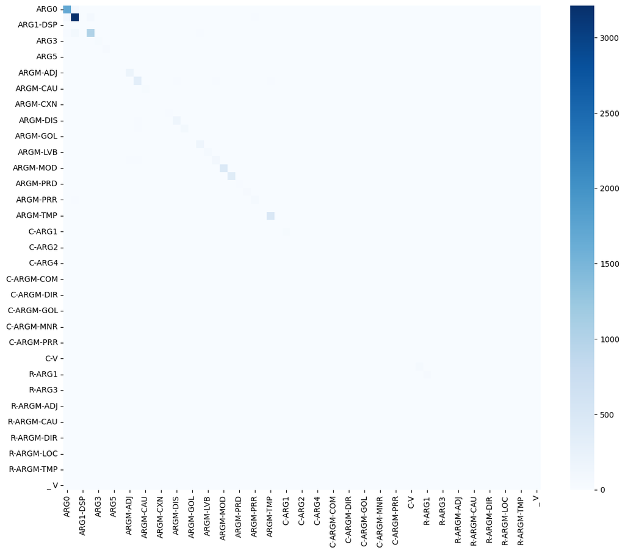

```python
if "O" in cm_df.index:
    cm_df_no_o = cm_df.drop(index="O", columns="O")

    plt.figure(figsize=(12, 10))
    sns.heatmap(cm_df_no_o, cmap="Blues")
    plt.tight_layout()

    plt.savefig(f"{out_dir}/best_model/confusion_matrix_no_O.png", dpi=300)
    plt.show()
    plt.close()
```

```python
total_tokens = 0

for example in tokenized_datasets["test"]:
    labels = example["labels"]
    total_tokens += sum(l != -100 for l in labels)

print("Total tokens to predict in the test set:", total_tokens)
```

```
Total tokens to predict in the test set: 111897
```

```python
print(f"The number of predicted tokens in confusion matrix: {cm_df.values.sum()}")
```

```
The number of predicted tokens in confusion matrix: 111897
```

We can conclude that the amount of tokens for SRL prediction is **the same** as the amount of tokens in confusion matrix

### Save predictions to tsv file

```python
import csv

output_file = f"{out_dir}/best_model/test_predictions.tsv"

with open(output_file, "w", newline="", encoding="utf-8") as f:
  writer = csv.writer(f, delimiter="\t")

  writer.writerow(["token", "gold_label", "predicted_label"])

  for example, pred, lab in zip(tokenized_datasets["test"], pred_ids, label_ids):
    tokens = example["tokens"]
    for token, p, l in zip(tokens, pred, lab):
      if l != -100:
        writer.writerow([token, id2label[l], id2label[p]])

    writer.writerow([])
```

## Custom sentence testing

```python
# run this cell if you want to load the model
CHECKPOINT_PATH = "/content/drive/MyDrive/SRL/best_model"   # change to your checkpoint path

tokenizer = AutoTokenizer.from_pretrained(CHECKPOINT_PATH)
model = AutoModelForTokenClassification.from_pretrained(CHECKPOINT_PATH)

device = torch.device("cuda" if torch.cuda.is_available() else "cpu")
model.to(device)
model.eval()

id2label = model.config.id2label
label2id = model.config.label2id
```

```python
# The function takes a string and return a list of predicted labels per token in the string
def predict_sentence_with_predicate(tokens, predicate_index, window=1, max_length: int = 128):

    if isinstance(tokens, str):
        words = tokens.split()
    else:
        words = tokens

    if not (0 <= predicate_index < len(words)):
        raise ValueError(f"predicate_index={predicate_index} out of range for {len(words)} tokens")

    query = make_predicate_query(words, predicate_index, window=window)

    enc = tokenizer(
        words,
        query,
        is_split_into_words=True,
        truncation=True,
        max_length=max_length,
        return_tensors="pt",
    )

    for k in enc:
        enc[k] = enc[k].to(device) # move to tensor

    with torch.no_grad():
        logits = model(**enc).logits  # [1, seq_len, num_labels]
        pred_ids = logits.argmax(dim=-1).squeeze(0).cpu().tolist()

    word_ids = enc.word_ids(batch_index=0)
    seq_ids = enc.sequence_ids(0)

    # Only for sequence A (seq_id == 0)
    first_subword_pred = {}
    for tok_pos, (w_id, s_id) in enumerate(zip(word_ids, seq_ids)):
        if w_id is None:
            continue
        if s_id != 0:
            continue  # ignore Sequence B and specials
        if w_id not in first_subword_pred:
            first_subword_pred[w_id] = pred_ids[tok_pos]

    results = []
    for w_i, w in enumerate(words):
        lab_id = first_subword_pred.get(w_i, label2id.get("O", 0))
        results.append((w, id2label[int(lab_id)]))

    return results
```

```python
string = "the police arrested him yesterday ."
pred_idx = 2  # "arrested"

preds = predict_sentence_with_predicate(string, pred_idx)
for tok, lab in preds:
    print(f"{tok:12s} {lab}")
```

```
the          O
police       ARG0
arrested     O
him          ARG1
yesterday    ARGM-TMP
.            O
```

```python
string = "I was kicked by him" # passive sentence
pred_idx = 2  # "kicked"

preds = predict_sentence_with_predicate(string, pred_idx)
for tok, lab in preds:
    print(f"{tok:12s} {lab}")
```

```
I            ARG1
was          O
kicked       O
by           O
him          ARG0
```

```python
string = "the old man boat" # gather path
pred_idx = 2  # "kicked"

preds = predict_sentence_with_predicate(string, pred_idx)
for tok, lab in preds:
    print(f"{tok:12s} {lab}")
```

```
the          O
old          ARGM-ADJ
man          O
boat         O
```

As seen from previous examples, the model could accurately predict simple active and passive sentences but failed in the simple garden path. This behaviour can be explained due to the superior common of "old" adjectivity over "the old" noun phrase in the training set.

The following code is used for removing widget created by Collab.

```python
# Deep clean widgets
import json
from copy import deepcopy

def clean_notebook_widgets(in_path, out_path=None):
    out_path = out_path or in_path
    with open(in_path, "r", encoding="utf-8") as f:
        nb = json.load(f)

    # Top-level metadata
    nb_meta = nb.get("metadata", {})
    # Remove common widget keys
    for k in ["widgets", "widget", "jupyter_widgets", "ipywidgets"]:
        if k in nb_meta:
            nb_meta.pop(k, None)
    nb["metadata"] = nb_meta

    # Per-cell metadata and outputs
    for cell in nb.get("cells", []):
        cell_meta = cell.get("metadata", {})
        for k in ["widgets", "widget", "jupyter_widgets", "ipywidgets"]:
            cell_meta.pop(k, None)
        # notebooks store widget state under these keys too
        for k in list(cell_meta.keys()):
            if "widget" in k.lower():
                cell_meta.pop(k, None)
        cell["metadata"] = cell_meta

        # Clean outputs metadata too
        if "outputs" in cell:
            for out in cell["outputs"]:
                out_meta = out.get("metadata", {})
                # Remove widget-related metadata
                for k in list(out_meta.keys()):
                    if "widget" in k.lower():
                        out_meta.pop(k, None)
                out["metadata"] = out_meta

                # widget outputs embed data that triggers nbconvert widget parsing
                data = out.get("data", {})
                if isinstance(data, dict):
                    # Common widget MIME types
                    data.pop("application/vnd.jupyter.widget-view+json", None)
                    data.pop("application/vnd.jupyter.widget-state+json", None)
                    out["data"] = data

    with open(out_path, "w", encoding="utf-8") as f:
        json.dump(nb, f, ensure_ascii=False, indent=1)

    return out_path

# ---- use it ----
nb_path = "bert_finetuning.ipynb"
clean_notebook_widgets(nb_path)
print("Deep-cleaned:", nb_path)
```

```
Deep-cleaned: bert_finetuning.ipynb
```